# Midterm Response - Spring 2017

Modern Data Mining

Your Name

20 March 2017

## Setup and Notes

We provide some glue code to load the data.

```r
exam_data_url <- "https://cdn.rawgit.com/stillmatic/6d065a8d0963c229b1daa61277ff2b60/raw/e7462da3cd1eadf5219e2d26942fc37bb72fd3ef/exam_data_final.csv"
county_data <- read.csv(exam_data_url)

# data is available on canvas too, on the exam assignment page
# county_data <- read.csv("exam_data_final.csv")

# for windows:
# library(httr) # v 1.2.1
# county_data <- httr::content(httr::GET("exam_data_url"))
```

## for code chunk output

Submit both this `Rmd` file and a knitted version (`html, pdf, or word`) to Canvas *before* 8 PM sharp!. The submissions will be closed after 8:00 PM.

You *must* name this file according to the following scheme: `LastName_FirstName_Midterm.rmd`, e.g. `Zhao_Linda_Midterm.rmd`.

## Part 1: Data Exploration

### Question 1

```r
## =============================  STANDARD EDA TECHNIQUES ==============================

## <<<< READING IN DATA >>>
# bill.data.test <- read.csv("Bills.subset.test.csv", header=TRUE, sep=",", na.strings="") # accounts for header, CSV, and na strings

#<<<<< SUMMARY STATS >>>>>>>>
dim(county_data)
```

```
## [1] 1077   27
```

```r
#sum.isna(county_data)
summary(county_data)
```

```
##         county          state     total_votes_12      dem12_frac
##  Washington:   9   Texas   :233   Min.   :     64   Min.   :0.03448
##  Jackson   :   8   Georgia :156   1st Qu.:   5036   1st Qu.:0.26101
##  Jefferson :   8   Kentucky:117   Median :  11872   Median :0.35268
##  Monroe    :   7   Missouri:111   Mean   :  46605   Mean   :0.36388
##  Montgomery:   7   Ohio    : 88   3rd Qu.:  30518   3rd Qu.:0.44806
##  Crawford  :   6   Michigan: 83   Max.   :3181067   Max.   :0.89734
##  (Other)   :1032   (Other) :289
##    rep12_frac      total_population  registered_voters reg_vote_frac
##  Min.   :0.09216   Min.   :     82   Min.   :    110   Min.   :0.3180
##  1st Qu.:0.53374   1st Qu.:  13446   1st Qu.:   8474   1st Qu.:0.5792
##  Median :0.63127   Median :  28673   Median :  18729   Median :0.6452
##  Mean   :0.62119   Mean   : 115312   Mean   :  69898   Mean   :0.6413
##  3rd Qu.:0.72680   3rd Qu.:  74386   3rd Qu.:  47513   3rd Qu.:0.7085
##  Max.   :0.95862   Max.   :9801950   Max.   :4758437   Max.   :1.5055
##
##     turnout       hs_diploma_degree median_income  poverty_frac
##  Min.   :0.2587   Min.   :0.2990    High  :359    Min.   :0.0000
##  1st Qu.:0.5839   1st Qu.:0.7650    Low   :359    1st Qu.:0.1205
##  Median :0.6468   Median :0.8290    Medium:359    Median :0.1560
##  Mean   :0.6509   Mean   :0.8124                  Mean   :0.1634
##  3rd Qu.:0.7094   3rd Qu.:0.8720                  3rd Qu.:0.1945
##  Max.   :0.9372   Max.   :0.9560                  Max.   :0.4515
##
##  caucasian_frac   gini_coefficient   median_age    adult_smoking
##  Min.   :0.0250   Min.   :0.2070   Min.   :24.10   Min.   :0.0790
##  1st Qu.:0.6605   1st Qu.:0.4090   1st Qu.:36.70   1st Qu.:0.1850
##  Median :0.8415   Median :0.4320   Median :39.20   Median :0.2190
##  Mean   :0.7765   Mean   :0.4338   Mean   :39.28   Mean   :0.2247
##  3rd Qu.:0.9415   3rd Qu.:0.4540   3rd Qu.:41.90   3rd Qu.:0.2590
##  Max.   :0.9900   Max.   :0.6260   Max.   :54.50   Max.   :0.4920
##
##    uninsured       unemployment     violent_crime    homicide_rate
##  Min.   :0.0600   Min.   :0.02300   Min.   :   0.0   Min.   : 0.890
##  1st Qu.:0.1460   1st Qu.:0.06300   1st Qu.: 122.2   1st Qu.: 3.726
##  Median :0.1910   Median :0.07700   Median : 202.2   Median : 7.282
##  Mean   :0.1938   Mean   :0.08044   Mean   : 247.3   Mean   : 7.619
##  3rd Qu.:0.2370   3rd Qu.:0.09500   3rd Qu.: 323.6   3rd Qu.:11.462
##  Max.   :0.3890   Max.   :0.28300   Max.   :1216.1   Max.   :27.040
##
##  infant_mortality african_american_frac  latino_frac     bachelors_degree
##  Min.   : 3.100   Min.   :0.00000       Min.   :0.0030   Min.   :0.0370
##  1st Qu.: 6.800   1st Qu.:0.00750       1st Qu.:0.0140   1st Qu.:0.1220
##  Median : 8.700   Median :0.02700       Median :0.0340   Median :0.1570
##  Mean   : 9.493   Mean   :0.07721       Mean   :0.1063   Mean   :0.1767
##  3rd Qu.:11.300   3rd Qu.:0.08850       3rd Qu.:0.1195   3rd Qu.:0.2070
##  Max.   :17.720   Max.   :0.74900       Max.   :0.9715   Max.   :0.5830
##
##  graduate_degree  competitive_state_08 margin_state_08
##  Min.   :0.0000   Mode :logical        Min.   :0.001334
##  1st Qu.:0.0400   FALSE:722            1st Qu.:0.052143
##  Median :0.0520   TRUE :355            Median :0.117692
##  Mean   :0.0612   NA's :0              Mean   :0.121862
##  3rd Qu.:0.0730                        3rd Qu.:0.162318
##  Max.   :0.2980                        Max.   :0.312902
##
```

```r
tail(county_data, 10)
```

```
##          county state total_votes_12 dem12_frac rep12_frac
## 1068 Tuscarawas  Ohio          41693  0.4414890  0.5334708
## 1069      Union  Ohio          25623  0.3436366  0.6357179
## 1070   Van Wert  Ohio          13898  0.2898978  0.6896676
## 1071     Vinton  Ohio           5490  0.4437158  0.5202186
## 1072     Warren  Ohio         111197  0.2959522  0.6885438
## 1073 Washington  Ohio          29602  0.3935883  0.5838795
## 1074      Wayne  Ohio          51165  0.3871396  0.5912440
## 1075   Williams  Ohio          17706  0.4103694  0.5674348
## 1076       Wood  Ohio          64059  0.5120592  0.4636975
## 1077    Wyandot  Ohio          10602  0.3902094  0.5829089
##      total_population registered_voters reg_vote_frac   turnout
## 1068          91912.5             59883     0.6515218 0.6962410
## 1069          49853.0             33823     0.6784547 0.7575614
## 1070          28795.0             20908     0.7260983 0.6647216
```

[output cut: 62 more lines]

```r
head(county_data, 20)
```

```
##          county      state total_votes_12 dem12_frac rep12_frac
## 1       Alameda California         595642  0.7885341  0.1816225
## 2        Alpine California            653  0.5957121  0.3614089
## 3        Amador California          17649  0.3869908  0.5825259
## 4         Butte California          90752  0.4701715  0.4901159
## 5     Calaveras California          21786  0.3979620  0.5675663
## 6        Colusa California           6034  0.3834935  0.5967849
## 7  Contra Costa California         438226  0.6636393  0.3115219
## 8     Del Norte California           8770  0.4322691  0.5261117
## 9     El Dorado California          88774  0.3961295  0.5741884
## 10       Fresno California         258827  0.4989008  0.4809776
## 11        Glenn California           9211  0.3583759  0.6114428
## 12     Humboldt California          57470  0.5995650  0.3275622
## 13     Imperial California          38565  0.6517827  0.3313108
## 14         Inyo California           8036  0.4258337  0.5400697
```

[output cut: 132 more lines]

```r
View(county_data)
#class(county_data)
names(county_data)
```

```
##  [1] "county"                "state"
##  [3] "total_votes_12"        "dem12_frac"
##  [5] "rep12_frac"            "total_population"
##  [7] "registered_voters"     "reg_vote_frac"
##  [9] "turnout"               "hs_diploma_degree"
## [11] "median_income"         "poverty_frac"
## [13] "caucasian_frac"        "gini_coefficient"
## [15] "median_age"            "adult_smoking"
## [17] "uninsured"             "unemployment"
## [19] "violent_crime"         "homicide_rate"
## [21] "infant_mortality"      "african_american_frac"
## [23] "latino_frac"           "bachelors_degree"
## [25] "graduate_degree"       "competitive_state_08"
## [27] "margin_state_08"
```

```r
county_data[1,"adult_smoking"] # row 1 of column "adult_smoking"
```

```
## [1] 0.106
```

```r
#<<<<< RENAME VARIABLES >>>>>>>>
#county_data <- county_data %>% rename(smoking_adults = adult_smoking ) # new = old name
names(county_data)
```

```
##  [1] "county"                "state"
##  [3] "total_votes_12"        "dem12_frac"
##  [5] "rep12_frac"            "total_population"
##  [7] "registered_voters"     "reg_vote_frac"
##  [9] "turnout"               "hs_diploma_degree"
## [11] "median_income"         "poverty_frac"
## [13] "caucasian_frac"        "gini_coefficient"
## [15] "median_age"            "adult_smoking"
## [17] "uninsured"             "unemployment"
## [19] "violent_crime"         "homicide_rate"
## [21] "infant_mortality"      "african_american_frac"
## [23] "latino_frac"           "bachelors_degree"
## [25] "graduate_degree"       "competitive_state_08"
## [27] "margin_state_08"
```

```r
# <<<<<<<<<< NA VALUES >>>>>>>>>
sum(is.na(county_data))
```

```
## [1] 0
```

```r
# show how many NA values in each column
sapply(county_data, function(x) sum(is.na(x)))
```

```
##                county                 state        total_votes_12
##                     0                     0                     0
##            dem12_frac            rep12_frac      total_population
##                     0                     0                     0
##     registered_voters         reg_vote_frac               turnout
##                     0                     0                     0
##     hs_diploma_degree         median_income          poverty_frac
##                     0                     0                     0
##        caucasian_frac      gini_coefficient            median_age
##                     0                     0                     0
##         adult_smoking             uninsured          unemployment
##                     0                     0                     0
##         violent_crime         homicide_rate      infant_mortality
##                     0                     0                     0
## african_american_frac           latino_frac      bachelors_degree
##                     0                     0                     0
##       graduate_degree  competitive_state_08       margin_state_08
##                     0                     0                     0
```

```r
# <<<<<< REMOVE A COLUMN >>>>>>>>
#remove a column
# county_data.mod <- county_data[,-1]
#head(county_data.mod)
#summary(county_data.mod)
#View(county_data.mod)

# <<<<<<<<<<<< GETTING DISTINCT VALUES IN A COLUMN >>>>>>>>>>>>
#county_data %>% county_data(,-1)
county_data %>% select(state) %>% distinct() # get distinct values for state column
```

```
##           state
## 1    California
## 2      Maryland
## 3      Michigan
## 4  Pennsylvania
## 5      Oklahoma
## 6         Texas
## 7     Wisconsin
## 8       Georgia
## 9      Kentucky
## 10     Missouri
## 11         Ohio
```

```r
county_data %>% select(median_income) %>% distinct() # get distince values for median_income column
```

```
##   median_income
## 1          High
## 2           Low
## 3        Medium
```

```r
#county_data %>% select(median_income)

# <<<<<<< MIN/MAX VALUES FOR A COLUMN >>>>>>>>>
min(county_data$uninsured)
```

```
## [1] 0.06
```

```r
max(county_data$uninsured)
```

```
## [1] 0.389
```

```r
min(county_data$poverty_frac)
```

```
## [1] 0
```

```r
max(county_data$poverty_frac)
```

```
## [1] 0.4515
```

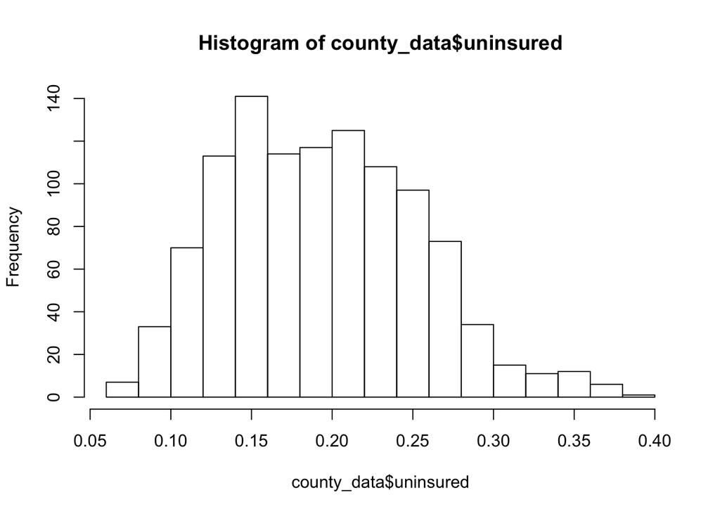

```r
# <<<<<<<<<<<<< PLOTS >>>>>>>>>>>>>>>>
#Histograms
hist(county_data$uninsured)
```

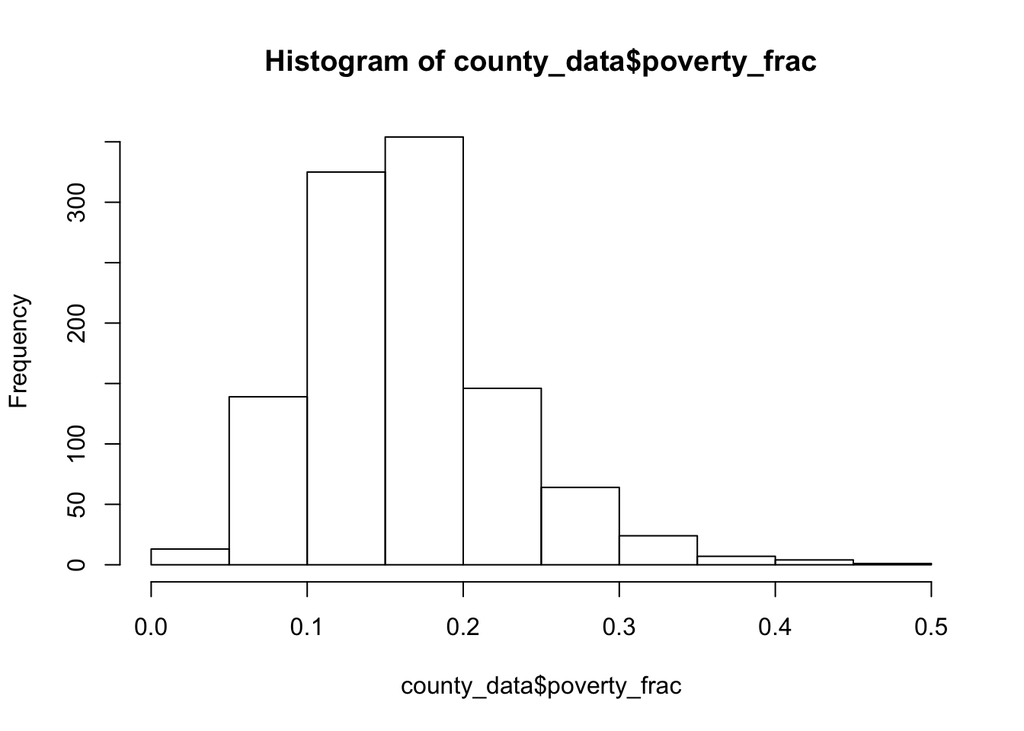

```r
hist(county_data$poverty_frac)
```

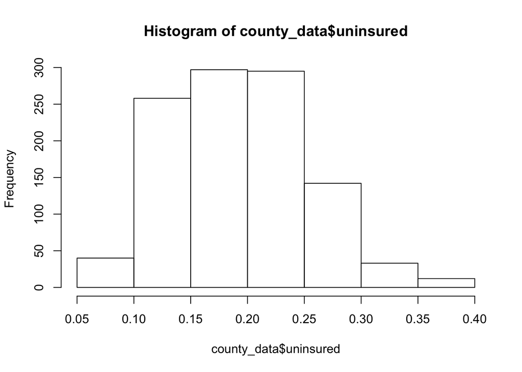

```r
hist(county_data$uninsured, breaks = 10)
```

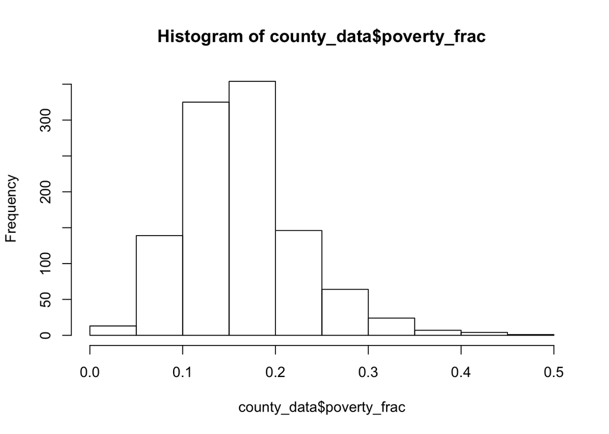

```r
hist(county_data$poverty_frac, breaks = 10)
```

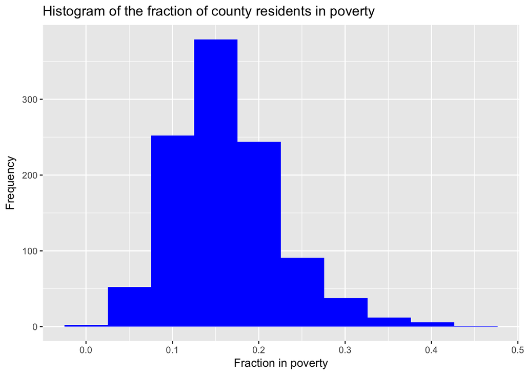

```r
# OR
ggplot(county_data) + geom_histogram(aes(x = poverty_frac), bins = 10, fill = "blue") +
  labs(title = "Histogram of the fraction of county residents in poverty", x = "Fraction in poverty", y = "Frequency")
```

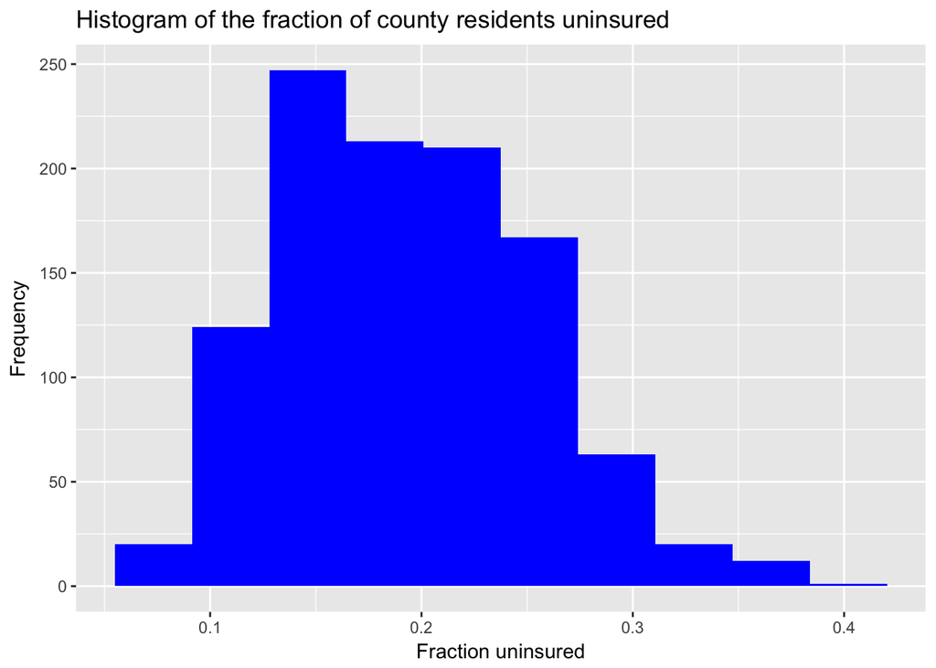

```r
ggplot(county_data) + geom_histogram(aes(x = uninsured), bins = 10, fill = "blue") +
  labs(title = "Histogram of the fraction of county residents uninsured", x = "Fraction uninsured", y = "Frequency")
```

```r
# using 2 columns to get info --- states with highest and lowest median age
county_data$state[which.max(county_data$median_age)] # of all states which has highest median age
```

```
## [1] Texas
## 11 Levels: California Georgia Kentucky Maryland Michigan Missouri ... Wisconsin
```

```r
county_data$state[which.min(county_data$median_age)]
```

```
## [1] Texas
## 11 Levels: California Georgia Kentucky Maryland Michigan Missouri ... Wisconsin
```

```r
county_data$state[which.max(county_data$graduate_degree)]
```

```
## [1] Maryland
## 11 Levels: California Georgia Kentucky Maryland Michigan Missouri ... Wisconsin
```

```r
county_data$county[which.max(county_data$median_age)]
```

```
## [1] Llano
## 804 Levels: Adair Adams Alameda Alcona Alfalfa Alger Allegan ... Zavala
```

```r
county_data$county[which.min(county_data$median_age)]
```

```
## [1] Brazos
## 804 Levels: Adair Adams Alameda Alcona Alfalfa Alger Allegan ... Zavala
```

```r
county_data$county[which.max(county_data$graduate_degree)]
```

```
## [1] Montgomery
## 804 Levels: Adair Adams Alameda Alcona Alfalfa Alger Allegan ... Zavala
```

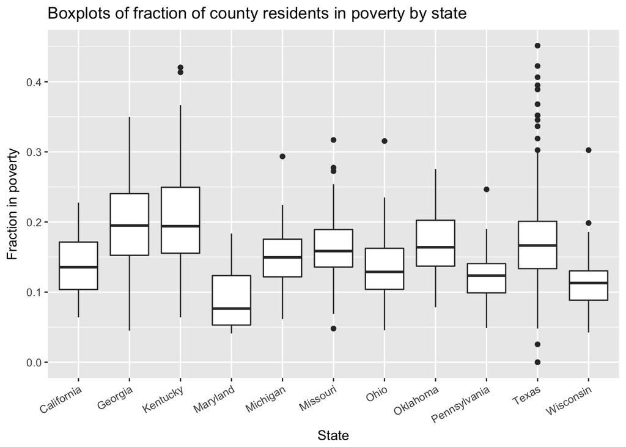

```r
# boxplot -- poverty fraction by state
# boxplot(county_data$state, county_data$poverty_frac) #nope
county_data %>% ggplot(aes(x = state, y = poverty_frac)) +
  geom_boxplot() +
  theme(axis.text.x = element_text(angle = 30, hjust = 1)) +
  labs(title = "Boxplots of fraction of county residents in poverty by state", x = "State", y = "Fraction in poverty")
```

```r
summary(county_data$poverty_frac)
```

```
##    Min. 1st Qu.  Median    Mean 3rd Qu.    Max.
##  0.0000  0.1205  0.1560  0.1634  0.1945  0.4515
```

## Part 2: Election Prediction

### Question 1

**1a. Answer goes here**

```r
names(county_data)
```

```
##  [1] "county"                "state"
##  [3] "total_votes_12"        "dem12_frac"
##  [5] "rep12_frac"            "total_population"
##  [7] "registered_voters"     "reg_vote_frac"
##  [9] "turnout"               "hs_diploma_degree"
## [11] "median_income"         "poverty_frac"
## [13] "caucasian_frac"        "gini_coefficient"
## [15] "median_age"            "adult_smoking"
## [17] "uninsured"             "unemployment"
## [19] "violent_crime"         "homicide_rate"
## [21] "infant_mortality"      "african_american_frac"
## [23] "latino_frac"           "bachelors_degree"
## [25] "graduate_degree"       "competitive_state_08"
## [27] "margin_state_08"
```

```r
summary(county_data)
```

```
##         county          state     total_votes_12      dem12_frac
##  Washington:   9   Texas   :233   Min.   :     64   Min.   :0.03448
##  Jackson   :   8   Georgia :156   1st Qu.:   5036   1st Qu.:0.26101
##  Jefferson :   8   Kentucky:117   Median :  11872   Median :0.35268
##  Monroe    :   7   Missouri:111   Mean   :  46605   Mean   :0.36388
##  Montgomery:   7   Ohio    : 88   3rd Qu.:  30518   3rd Qu.:0.44806
##  Crawford  :   6   Michigan: 83   Max.   :3181067   Max.   :0.89734
##  (Other)   :1032   (Other) :289
##    rep12_frac      total_population  registered_voters reg_vote_frac
##  Min.   :0.09216   Min.   :     82   Min.   :    110   Min.   :0.3180
##  1st Qu.:0.53374   1st Qu.:  13446   1st Qu.:   8474   1st Qu.:0.5792
##  Median :0.63127   Median :  28673   Median :  18729   Median :0.6452
##  Mean   :0.62119   Mean   : 115312   Mean   :  69898   Mean   :0.6413
##  3rd Qu.:0.72680   3rd Qu.:  74386   3rd Qu.:  47513   3rd Qu.:0.7085
##  Max.   :0.95862   Max.   :9801950   Max.   :4758437   Max.   :1.5055
##
##     turnout       hs_diploma_degree median_income  poverty_frac
##  Min.   :0.2587   Min.   :0.2990    High  :359    Min.   :0.0000
##  1st Qu.:0.5839   1st Qu.:0.7650    Low   :359    1st Qu.:0.1205
##  Median :0.6468   Median :0.8290    Medium:359    Median :0.1560
##  Mean   :0.6509   Mean   :0.8124                  Mean   :0.1634
##  3rd Qu.:0.7094   3rd Qu.:0.8720                  3rd Qu.:0.1945
##  Max.   :0.9372   Max.   :0.9560                  Max.   :0.4515
##
##  caucasian_frac   gini_coefficient   median_age    adult_smoking
##  Min.   :0.0250   Min.   :0.2070   Min.   :24.10   Min.   :0.0790
##  1st Qu.:0.6605   1st Qu.:0.4090   1st Qu.:36.70   1st Qu.:0.1850
##  Median :0.8415   Median :0.4320   Median :39.20   Median :0.2190
##  Mean   :0.7765   Mean   :0.4338   Mean   :39.28   Mean   :0.2247
##  3rd Qu.:0.9415   3rd Qu.:0.4540   3rd Qu.:41.90   3rd Qu.:0.2590
##  Max.   :0.9900   Max.   :0.6260   Max.   :54.50   Max.   :0.4920
##
##    uninsured       unemployment     violent_crime    homicide_rate
##  Min.   :0.0600   Min.   :0.02300   Min.   :   0.0   Min.   : 0.890
##  1st Qu.:0.1460   1st Qu.:0.06300   1st Qu.: 122.2   1st Qu.: 3.726
##  Median :0.1910   Median :0.07700   Median : 202.2   Median : 7.282
##  Mean   :0.1938   Mean   :0.08044   Mean   : 247.3   Mean   : 7.619
##  3rd Qu.:0.2370   3rd Qu.:0.09500   3rd Qu.: 323.6   3rd Qu.:11.462
##  Max.   :0.3890   Max.   :0.28300   Max.   :1216.1   Max.   :27.040
##
##  infant_mortality african_american_frac  latino_frac     bachelors_degree
##  Min.   : 3.100   Min.   :0.00000       Min.   :0.0030   Min.   :0.0370
##  1st Qu.: 6.800   1st Qu.:0.00750       1st Qu.:0.0140   1st Qu.:0.1220
##  Median : 8.700   Median :0.02700       Median :0.0340   Median :0.1570
##  Mean   : 9.493   Mean   :0.07721       Mean   :0.1063   Mean   :0.1767
##  3rd Qu.:11.300   3rd Qu.:0.08850       3rd Qu.:0.1195   3rd Qu.:0.2070
##  Max.   :17.720   Max.   :0.74900       Max.   :0.9715   Max.   :0.5830
##
##  graduate_degree  competitive_state_08 margin_state_08
##  Min.   :0.0000   Mode :logical        Min.   :0.001334
##  1st Qu.:0.0400   FALSE:722            1st Qu.:0.052143
##  Median :0.0520   TRUE :355            Median :0.117692
##  Mean   :0.0612   NA's :0              Mean   :0.121862
##  3rd Qu.:0.0730                        3rd Qu.:0.162318
##  Max.   :0.2980                        Max.   :0.312902
##
```

```r
summary(county_data$median_income)
```

```
##   High    Low Medium
##    359    359    359
```

```r
lmfit0 <- lm(dem12_frac~median_income, data = county_data)
names(lmfit0)
```

```
##  [1] "coefficients"  "residuals"     "effects"       "rank"
##  [5] "fitted.values" "assign"        "qr"            "df.residual"
##  [9] "contrasts"     "xlevels"       "call"          "terms"
## [13] "model"
```

```r
lmfit0$coefficients
```

```
##         (Intercept)    median_incomeLow median_incomeMedium
##          0.39090676         -0.02744645         -0.05362440
```

```r
summary(lmfit0)
```

```
##
## Call:
## lm(formula = dem12_frac ~ median_income, data = county_data)
##
## Residuals:
##      Min       1Q   Median       3Q      Max
## -0.35642 -0.09642 -0.01081  0.08675  0.50643
##
## Coefficients:
##                      Estimate Std. Error t value Pr(>|t|)
## (Intercept)          0.390907   0.007483  52.236  < 2e-16 ***
## median_incomeLow    -0.027446   0.010583  -2.593  0.00963 **
## median_incomeMedium -0.053624   0.010583  -5.067 4.76e-07 ***
## ---
## Signif. codes:  0 '***' 0.001 '**' 0.01 '*' 0.05 '.' 0.1 ' ' 1
##
## Residual standard error: 0.1418 on 1074 degrees of freedom
## Multiple R-squared:  0.02335,    Adjusted R-squared:  0.02153
## F-statistic: 12.84 on 2 and 1074 DF,  p-value: 3.088e-06
```

According to the summary statistics, when fitting a simple linear model predicting `dem12_frac` using only `median_income` we see that both `LOW` and `MEDIUM` median income levels are significant at the .01 level.

**1b. Answer goes here**

According to the linear model discribed above, counties with a low median income are 2.7% *less* likely to vote democrat with all else being equal. Similarly, counties with medium median incomes are 5.4% less likely to vote democratic when all else is equal. According to this model, high median income counties are most advantageous for democratic candidates, as both low and medium median income counties represent a decrease in percent of voters for the party.

### Question 2

#### 2a)

```r
lmfit1 <- lm(dem12_frac~median_income + state, data = county_data)
summary(lmfit1)
```

```
##
## Call:
## lm(formula = dem12_frac ~ median_income + state, data = county_data)
##
## Residuals:
##      Min       1Q   Median       3Q      Max
## -0.24536 -0.07164 -0.01190  0.05260  0.56957
##
## Coefficients:
##                      Estimate Std. Error t value Pr(>|t|)
## (Intercept)          0.515481   0.015777  32.674  < 2e-16 ***
## median_incomeLow     0.023036   0.009298   2.478  0.01338 *
## median_incomeMedium -0.016859   0.008994  -1.875  0.06113 .
## stateGeorgia        -0.148974   0.018161  -8.203 6.71e-16 ***
## stateKentucky       -0.205301   0.019068 -10.767  < 2e-16 ***
## stateMaryland       -0.049183   0.029922  -1.644  0.10053
## stateMichigan       -0.057471   0.020220  -2.842  0.00456 **
## stateMissouri       -0.199465   0.019335 -10.316  < 2e-16 ***
## stateOhio           -0.089702   0.019853  -4.518 6.93e-06 ***
## stateOklahoma       -0.244856   0.020863 -11.736  < 2e-16 ***
## statePennsylvania   -0.103896   0.021128  -4.917 1.02e-06 ***
## stateTexas          -0.244665   0.017366 -14.089  < 2e-16 ***
## stateWisconsin      -0.009193   0.020752  -0.443  0.65786
## ---
## Signif. codes:  0 '***' 0.001 '**' 0.01 '*' 0.05 '.' 0.1 ' ' 1
##
## Residual standard error: 0.1172 on 1064 degrees of freedom
## Multiple R-squared:  0.3385, Adjusted R-squared:  0.331
## F-statistic: 45.37 on 12 and 1064 DF,  p-value: < 2.2e-16
```

```r
Anova(lmfit1)
```

```
## Anova Table (Type II tests)
##
## Response: dem12_frac
##                Sum Sq   Df F value    Pr(>F)
## median_income  0.2771    2  10.079 4.608e-05 ***
## state          6.9678   10  50.692 < 2.2e-16 ***
## Residuals     14.6249 1064
## ---
## Signif. codes:  0 '***' 0.001 '**' 0.01 '*' 0.05 '.' 0.1 ' ' 1
```

```r
summary(lmfit1)$coefficients
```

```
##                         Estimate  Std. Error     t value      Pr(>|t|)
## (Intercept)          0.515481072 0.015776552  32.6738749 1.003599e-162
## median_incomeLow     0.023036146 0.009298003   2.4775368  1.338366e-02
## median_incomeMedium -0.016858678 0.008993563  -1.8745273  6.113159e-02
## stateGeorgia        -0.148974389 0.018160762  -8.2030915  6.705298e-16
## stateKentucky       -0.205301317 0.019067603 -10.7670231  9.867332e-26
## stateMaryland       -0.049182790 0.029921679  -1.6437176  1.005300e-01
## stateMichigan       -0.057470575 0.020219825  -2.8422885  4.564679e-03
## stateMissouri       -0.199465021 0.019334822 -10.3163619  7.563603e-24
## stateOhio           -0.089701835 0.019852919  -4.5183198  6.930434e-06
## stateOklahoma       -0.244855716 0.020863345 -11.7361675  5.368593e-30
## statePennsylvania   -0.103895822 0.021128428  -4.9173475  1.015546e-06
## stateTexas          -0.244664580 0.017365718 -14.0889415  1.845489e-41
## stateWisconsin      -0.009193073 0.020752087  -0.4429951  6.578593e-01
```

Yes, according to the F-test `median_income` is still significant in this new model at the 5% level, and we can reject $H_0$ that it isn’t needed.

#### 2B)

According to the above model if we hold state values equal, a low median income county will be associated with a corresponding 2.3% increase in percent population that votes democratic, while a medium median income county would be associated with a 1.7% drop in population that votes democratic.

This outcome differs from the first linear model in 1 very important way: this model implies that low median income counties are the most fruitful in terms of votes for the democratic party, while the first model implied that high median income communities would produce the most votes in favor of the party.

### Question 3

#### 3A)

```r
#install.packages('ISwR')
library(ISwR)
lmfit.full <- lm(dem12_frac~., data = county_data)
summary(lmfit.full)
```

```
##
## Call:
## lm(formula = dem12_frac ~ ., data = county_data)
##
## Residuals:
##       Min        1Q    Median        3Q       Max
## -0.008522  0.000000  0.000000  0.000000  0.008522
##
## Coefficients: (2 not defined because of singularities)
##                            Estimate Std. Error  t value Pr(>|t|)
## (Intercept)               9.628e-01  1.143e-02   84.226  < 2e-16 ***
## countyAdams               1.844e-03  2.751e-03    0.670 0.503290
## countyAlameda             3.022e-03  5.018e-03    0.602 0.547613
## countyAlcona              3.356e-03  4.025e-03    0.834 0.405264
## countyAlfalfa             4.634e-04  3.987e-03    0.116 0.907578
## countyAlger              -3.955e-03  4.022e-03   -0.983 0.326434
## countyAllegan            -1.511e-03  3.809e-03   -0.397 0.691833
## countyAllegany           -1.698e-03  4.149e-03   -0.409 0.682810
## countyAllegheny           4.698e-03  4.579e-03    1.026 0.306016
## countyAllen               1.822e-03  2.999e-03    0.608 0.544009
## countyAlpena              2.792e-03  3.856e-03    0.724 0.469657
## countyAlpine              1.103e-03  5.011e-03    0.220 0.825936
## countyAmador              1.047e-02  4.678e-03    2.239 0.026088 *
## countyAnderson            2.601e-05  3.046e-03    0.009 0.993192
## countyAndrew             -8.934e-04  3.831e-03   -0.233 0.815822
## countyAndrews            -1.818e-03  3.990e-03   -0.456 0.649108
## countyAngelina            2.138e-03  3.777e-03    0.566 0.571924
## countyAnne Arundel       -3.230e-03  4.095e-03   -0.789 0.431014
## countyAntrim              3.203e-04  3.882e-03    0.083 0.934313
## countyAppling            -1.643e-03  3.810e-03   -0.431 0.666632
## countyAransas             4.256e-03  3.882e-03    1.096 0.274000
## countyArcher              4.301e-03  3.822e-03    1.125 0.261584
## countyArenac             -8.947e-04  3.896e-03   -0.230 0.818551
## countyArmstrong           3.180e-03  3.091e-03    1.029 0.304618
## countyAshland             7.074e-04  3.015e-03    0.235 0.814693
## countyAshtabula           4.753e-04  3.828e-03    0.124 0.901304
## countyAtascosa            1.758e-03  4.074e-03    0.432 0.666404
## countyAtchison            5.025e-03  4.004e-03    1.255 0.210682
## countyAthens             -3.223e-03  3.999e-03   -0.806 0.421099
## countyAtkinson            1.760e-03  3.963e-03    0.444 0.657428
```

[output cut: 800 more lines]

```
## violent_crime            -2.028e-06  1.580e-06   -1.284 0.200501
## homicide_rate            -8.786e-05  7.397e-05   -1.188 0.236110
## infant_mortality          1.007e-04  9.718e-05    1.037 0.300959
## african_american_frac     1.348e-02  5.270e-03    2.558 0.011139 *
## latino_frac              -4.780e-03  5.637e-03   -0.848 0.397310
## bachelors_degree         -1.914e-02  1.073e-02   -1.784 0.075610 .
## graduate_degree           1.834e-02  2.144e-02    0.855 0.393141
## competitive_state_08TRUE         NA         NA       NA       NA
## margin_state_08                  NA         NA       NA       NA
## ---
## Signif. codes:  0 '***' 0.001 '**' 0.01 '*' 0.05 '.' 0.1 ' ' 1
##
## Residual standard error: 0.003133 on 240 degrees of freedom
## Multiple R-squared:  0.9999, Adjusted R-squared:  0.9995
## F-statistic:  2694 on 836 and 240 DF,  p-value: < 2.2e-16
```

```r
Anova(lmfit.full)
```

```
## Anova Table (Type II tests)
##
## Response: dem12_frac
##                        Sum Sq  Df    F value    Pr(>F)
## county                0.01153 803     1.4632 0.0002241 ***
## state                 0.00583  10    59.3833 < 2.2e-16 ***
## total_votes_12        0.00007   1     6.6575 0.0104694 *
## rep12_frac            0.81643   1 83190.6944 < 2.2e-16 ***
## total_population      0.00003   1     3.3027 0.0704153 .
## registered_voters     0.00006   1     5.8005 0.0167762 *
## reg_vote_frac         0.00007   1     7.3402 0.0072288 **
## turnout               0.00004   1     3.8105 0.0520945 .
## hs_diploma_degree     0.00002   1     1.8000 0.1809783
## median_income         0.00004   2     2.1294 0.1211547
## poverty_frac          0.00000   1     0.0532 0.8177979
## caucasian_frac        0.00016   1    16.0592 8.196e-05 ***
## gini_coefficient      0.00001   1     1.1176 0.2914977
## median_age            0.00000   1     0.4465 0.5046420
## adult_smoking         0.00000   1     0.0240 0.8771136
## uninsured             0.00001   1     1.1806 0.2783312
## unemployment          0.00000   1     0.4329 0.5111954
## violent_crime         0.00002   1     1.6478 0.2005012
## homicide_rate         0.00001   1     1.4107 0.2361095
## infant_mortality      0.00001   1     1.0746 0.3009593
## african_american_frac 0.00006   1     6.5441 0.0111387 *
## latino_frac           0.00001   1     0.7190 0.3973103
## bachelors_degree      0.00003   1     3.1843 0.0756103 .
## graduate_degree       0.00001   1     0.7318 0.3931414
## competitive_state_08            0
## margin_state_08                 0
## Residuals             0.00236 240
## ---
## Signif. codes:  0 '***' 0.001 '**' 0.01 '*' 0.05 '.' 0.1 ' ' 1
```

```r
# cor(county_data[name.num])

# <<<<<<<< CONFIDENCE INTERVAL >>>>>>>>
confint(lmfit1) # default 95% CI == beta +- 1.96 * SE(beta hat)
```

```
##                           2.5 %        97.5 %
## (Intercept)          0.48452438  0.5464377590
## median_incomeLow     0.00479164  0.0412806518
## median_incomeMedium -0.03450581  0.0007884548
## stateGeorgia        -0.18460936 -0.1133394142
## stateKentucky       -0.24271569 -0.1678869422
## stateMaryland       -0.10789499  0.0095294103
## stateMichigan       -0.09714583 -0.0177953147
## stateMissouri       -0.23740373 -0.1615263095
## stateOhio           -0.12865715 -0.0507465166
## stateOklahoma       -0.28579369 -0.2039177419
## statePennsylvania   -0.14535394 -0.0624377041
## stateTexas          -0.27873952 -0.2105896378
## stateWisconsin      -0.04991274  0.0315265906
```

```r
confint(lmfit.full)
```

```
##                                  2.5 %        97.5 %
## (Intercept)               9.403105e-01  9.853485e-01
## countyAdams              -3.575681e-03  7.264456e-03
## countyAlameda            -6.863757e-03  1.290793e-02
## countyAlcona             -4.572785e-03  1.128384e-02
## countyAlfalfa            -7.390811e-03  8.317541e-03
## countyAlger              -1.187889e-02  3.968297e-03
## countyAllegan            -9.014371e-03  5.991377e-03
## countyAllegany           -9.871243e-03  6.476067e-03
## countyAllegheny          -4.323363e-03  1.371848e-02
## countyAllen              -4.085187e-03  7.729499e-03
## countyAlpena             -4.803047e-03  1.038749e-02
## countyAlpine             -8.767535e-03  1.097385e-02
## countyAmador              1.257829e-03  1.968897e-02
## countyAnderson           -5.973673e-03  6.025703e-03
## countyAndrew             -8.440907e-03  6.654098e-03
## countyAndrews            -9.677469e-03  6.042050e-03
## countyAngelina           -5.302748e-03  9.578479e-03
## countyAnne Arundel       -1.129820e-02  4.837231e-03
## countyAntrim             -7.327572e-03  7.968213e-03
## countyAppling            -9.148305e-03  5.861848e-03
## countyAransas            -3.390793e-03  1.190302e-02
## countyArcher             -3.227841e-03  1.182916e-02
## countyArenac             -8.568764e-03  6.779393e-03
## countyArmstrong          -2.908576e-03  9.267597e-03
## countyAshland            -5.231697e-03  6.646506e-03
## countyAshtabula          -7.066370e-03  8.016939e-03
## countyAtascosa           -6.266498e-03  9.783110e-03
## countyAtchison           -2.862059e-03  1.291176e-02
## countyAthens             -1.110121e-02  4.655165e-03
## countyAtkinson           -6.047759e-03  9.567475e-03
## countyAtoka              -8.094839e-03  6.714871e-03
## countyAudrain            -8.015644e-03  6.911418e-03
## countyAuglaize           -6.264657e-03  8.743623e-03
## countyAustin             -9.653806e-03  5.341865e-03
## countyBacon              -8.251426e-03  6.987434e-03
## countyBailey             -1.005532e-03  1.461129e-02
## countyBaker              -9.049396e-03  7.207051e-03
## countyBaldwin            -6.538563e-03  8.531889e-03
## countyBallard            -8.054533e-03  7.090923e-03
```

[output cut: 785 more lines]

```
## caucasian_frac           -2.895118e-02 -9.868672e-03
## gini_coefficient         -8.267525e-03  2.741924e-02
## median_age               -2.613954e-04  1.289770e-04
## adult_smoking            -7.913787e-03  9.263582e-03
## uninsured                -3.351495e-02  9.686372e-03
## unemployment             -4.235885e-02  2.114737e-02
## violent_crime            -5.139141e-06  1.083956e-06
## homicide_rate            -2.335698e-04  5.785593e-05
## infant_mortality         -9.069332e-05  2.921624e-04
## african_american_frac     3.099864e-03  2.386135e-02
## latino_frac              -1.588504e-02  6.324747e-03
## bachelors_degree         -4.026591e-02  1.988713e-03
## graduate_degree          -2.389214e-02  6.057325e-02
## competitive_state_08TRUE            NA            NA
## margin_state_08                     NA            NA
```

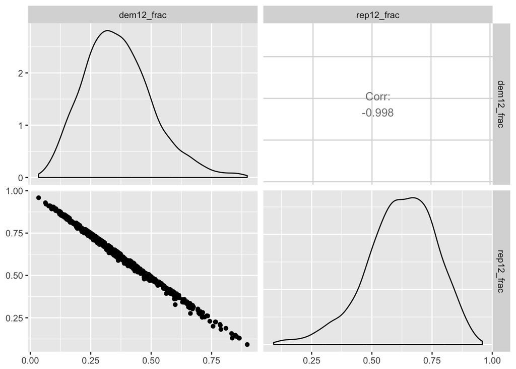

```r
# <<<<< CORRELATION OF VARIABLES >>>>>>>>>
county_data %>%
  select_if(is.numeric) %>%
  select(dem12_frac, rep12_frac) %>%
  ggpairs()
```

```r
# x <- county_data$dem12_frac
# y <- county_data$county
# cor(x, y)

#summary(lmfit.full)$coefficients

county_data %>% select(dem12_frac, rep12_frac) %>% cor()
```

```
##            dem12_frac rep12_frac
## dem12_frac  1.0000000 -0.9984352
## rep12_frac -0.9984352  1.0000000
```

#### 3B)

TODO: build a model using LASSO excluding `county` and `rep12_frac`, and `state`. Why use LASSO? Good if p (# parameters/variables) is really large – forward stepwise selection an option, but backwards stepwise selection and exhaustive certainly are not. LASSO adds constraints to the coefficients – L1 penalty, λ is tuning parameter. Best lambda is chosen by k-fold cross validation. Use: `glmnet()`

```r
#<<<<<<<<<<< LASSO >>>>>>>>>>>>>>
set.seed(34)
names(county_data)
```

```
##  [1] "county"                "state"
##  [3] "total_votes_12"        "dem12_frac"
##  [5] "rep12_frac"            "total_population"
##  [7] "registered_voters"     "reg_vote_frac"
##  [9] "turnout"               "hs_diploma_degree"
## [11] "median_income"         "poverty_frac"
## [13] "caucasian_frac"        "gini_coefficient"
## [15] "median_age"            "adult_smoking"
## [17] "uninsured"             "unemployment"
## [19] "violent_crime"         "homicide_rate"
## [21] "infant_mortality"      "african_american_frac"
## [23] "latino_frac"           "bachelors_degree"
## [25] "graduate_degree"       "competitive_state_08"
## [27] "margin_state_08"
```

```r
# extract y, dem12_frac, which is the 4th column
#Y <- county_data[,4]
Y <- county_data$dem12_frac
#Y
# county_data$dem12_frac
X <- model.matrix(dem12_frac~. -county -rep12_frac -state, data = county_data)[, -1]
#X
colnames(X)
```

```
##  [1] "total_votes_12"           "total_population"
##  [3] "registered_voters"        "reg_vote_frac"
##  [5] "turnout"                  "hs_diploma_degree"
##  [7] "median_incomeLow"         "median_incomeMedium"
##  [9] "poverty_frac"             "caucasian_frac"
## [11] "gini_coefficient"         "median_age"
## [13] "adult_smoking"            "uninsured"
## [15] "unemployment"             "violent_crime"
## [17] "homicide_rate"            "infant_mortality"
## [19] "african_american_frac"    "latino_frac"
## [21] "bachelors_degree"         "graduate_degree"
## [23] "competitive_state_08TRUE" "margin_state_08"
```

```r
fit.lasso.cv <- cv.glmnet(X, Y, alpha = 1, nfolds = 10)
fit.lasso.cv$lambda.1se
```

```
## [1] 0.002052096
```

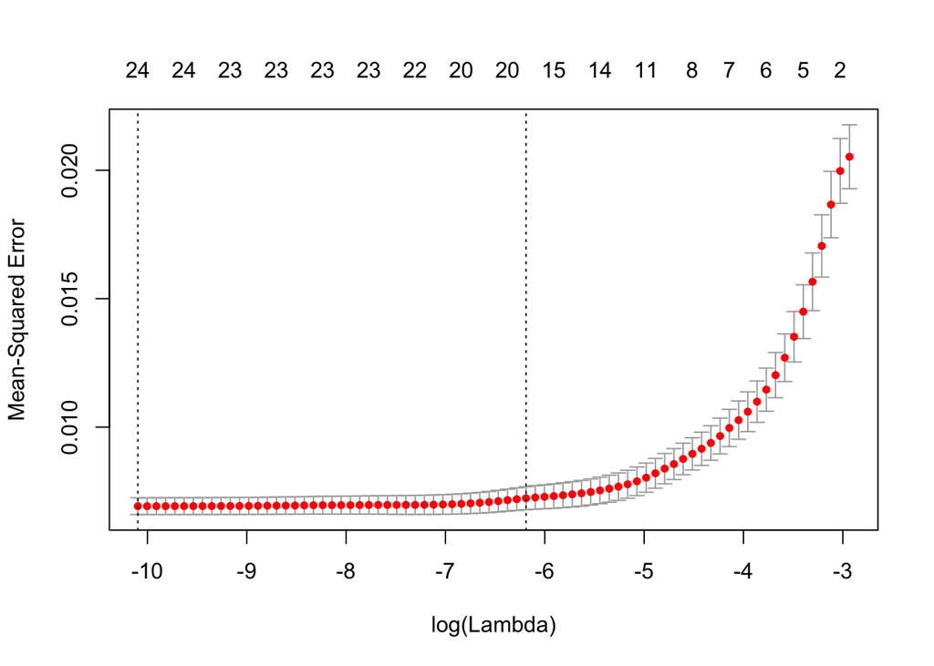

```r
plot(fit.lasso.cv) # plots the possible values for lambda
```

```r
# <<<<<<<< COEFFICIENTS FROM LASSO, WITH 10 FOLD CROSS VALIDATION USING LAMBDA.1SE >>>>>>>>
# can choose any value between lambda.min and lambda.1se
coef_1se <- coef(fit.lasso.cv, s = 'lambda.1se')
nzcoef <- rownames(coef_1se)[which((coef_1se) != 0)]
nzcoef
```

```
##  [1] "(Intercept)"         "total_votes_12"      "registered_voters"
##  [4] "reg_vote_frac"       "turnout"             "hs_diploma_degree"
##  [7] "median_incomeLow"    "median_incomeMedium" "poverty_frac"
## [10] "caucasian_frac"      "gini_coefficient"    "median_age"
## [13] "adult_smoking"       "uninsured"           "unemployment"
## [16] "violent_crime"       "infant_mortality"    "latino_frac"
## [19] "graduate_degree"     "margin_state_08"
```

```r
lm.input <- as.formula(paste("dem12_frac", "~", paste(nzcoef[-1], collapse = "+")))
# print <-  as.formula(paste(nzcoef[-1], collapse = "/n"))
lm.input
```

```
## dem12_frac ~ total_votes_12 + registered_voters + reg_vote_frac +
##     turnout + hs_diploma_degree + median_incomeLow + median_incomeMedium +
##     poverty_frac + caucasian_frac + gini_coefficient + median_age +
##     adult_smoking + uninsured + unemployment + violent_crime +
##     infant_mortality + latino_frac + graduate_degree + margin_state_08
```

```r
# THIS WAY DIDN'T WORK TO GET THE COEFFICIENTS, but above did
# coef.min.1se <- coef(fit.lasso.cv, s="lambda.1se") #using 1se
# coef.min.1se <- coef.min.1se[which(coef.min.1se != 0)]
# coef.min.1se # set of predictors chosen
# rownames(as.matrix(coef.min.1se))
```

#### 3C)

```r
fit.ols.cv <- (lm(dem12_frac ~ total_votes_12 + registered_voters + reg_vote_frac +
    turnout + hs_diploma_degree + median_income +
    poverty_frac + caucasian_frac + gini_coefficient + median_age +
    adult_smoking + uninsured + unemployment + violent_crime +
    infant_mortality + latino_frac + bachelors_degree + graduate_degree +
    margin_state_08, county_data))
summary(fit.ols.cv)
```

```
##
## Call:
## lm(formula = dem12_frac ~ total_votes_12 + registered_voters +
##     reg_vote_frac + turnout + hs_diploma_degree + median_income +
##     poverty_frac + caucasian_frac + gini_coefficient + median_age +
##     adult_smoking + uninsured + unemployment + violent_crime +
##     infant_mortality + latino_frac + bachelors_degree + graduate_degree +
##     margin_state_08, data = county_data)
##
## Residuals:
##      Min       1Q   Median       3Q      Max
## -0.25520 -0.04974 -0.00108  0.04605  0.35605
##
## Coefficients:
##                       Estimate Std. Error t value Pr(>|t|)
## (Intercept)          1.389e-01  8.705e-02   1.596  0.11075
## total_votes_12      -1.303e-08  1.678e-07  -0.078  0.93810
## registered_voters    8.747e-08  1.101e-07   0.794  0.42723
## reg_vote_frac        2.505e-01  3.943e-02   6.354 3.12e-10 ***
## turnout              2.925e-01  4.335e-02   6.747 2.48e-11 ***
## hs_diploma_degree    5.470e-01  6.213e-02   8.804  < 2e-16 ***
## median_incomeLow     2.799e-02  8.625e-03   3.245  0.00121 **
## median_incomeMedium  1.508e-02  7.278e-03   2.072  0.03854 *
## poverty_frac         8.065e-01  8.138e-02   9.910  < 2e-16 ***
## caucasian_frac      -5.113e-01  2.868e-02 -17.827  < 2e-16 ***
## gini_coefficient    -2.699e-01  1.002e-01  -2.693  0.00720 **
## median_age           1.119e-03  8.972e-04   1.247  0.21250
## adult_smoking        1.102e-01  5.572e-02   1.978  0.04823 *
## uninsured           -1.602e+00  7.615e-02 -21.044  < 2e-16 ***
## unemployment         8.032e-01  1.120e-01   7.173 1.38e-12 ***
## violent_crime        1.749e-05  1.726e-05   1.013  0.31123
## infant_mortality    -2.384e-03  1.056e-03  -2.257  0.02421 *
## latino_frac          1.301e-01  3.262e-02   3.988 7.12e-05 ***
## bachelors_degree    -5.797e-01  1.139e-01  -5.091 4.22e-07 ***
## graduate_degree      1.273e+00  2.297e-01   5.543 3.76e-08 ***
## margin_state_08     -1.547e-02  3.315e-02  -0.467  0.64091
## ---
## Signif. codes:  0 '***' 0.001 '**' 0.01 '*' 0.05 '.' 0.1 ' ' 1
##
## Residual standard error: 0.08167 on 1056 degrees of freedom
## Multiple R-squared:  0.6814, Adjusted R-squared:  0.6754
## F-statistic: 112.9 on 20 and 1056 DF,  p-value: < 2.2e-16
```

```r
Anova(fit.ols.cv)
```

```
## Anova Table (Type II tests)
##
## Response: dem12_frac
##                   Sum Sq   Df  F value    Pr(>F)
## total_votes_12    0.0000    1   0.0060  0.938097
## registered_voters 0.0042    1   0.6308  0.427233
## reg_vote_frac     0.2693    1  40.3716 3.116e-10 ***
## turnout           0.3037    1  45.5268 2.477e-11 ***
## hs_diploma_degree 0.5170    1  77.5043 < 2.2e-16 ***
## median_income     0.0703    2   5.2677  0.005292 **
## poverty_frac      0.6551    1  98.2071 < 2.2e-16 ***
## caucasian_frac    2.1199    1 317.8181 < 2.2e-16 ***
## gini_coefficient  0.0484    1   7.2508  0.007199 **
## median_age        0.0104    1   1.5562  0.212501
## adult_smoking     0.0261    1   3.9110  0.048232 *
## uninsured         2.9539    1 442.8426 < 2.2e-16 ***
## unemployment      0.3432    1  51.4561 1.376e-12 ***
## violent_crime     0.0068    1   1.0264  0.311232
## infant_mortality  0.0340    1   5.0939  0.024214 *
## latino_frac       0.1061    1  15.9039 7.123e-05 ***
## bachelors_degree  0.1729    1  25.9165 4.219e-07 ***
## graduate_degree   0.2049    1  30.7241 3.756e-08 ***
## margin_state_08   0.0015    1   0.2177  0.640913
## Residuals         7.0438 1056
## ---
## Signif. codes:  0 '***' 0.001 '**' 0.01 '*' 0.05 '.' 0.1 ' ' 1
```

Not all variables are significant at the .05 level. In particular, the following 5 variables seem to contribute little to the model: `total_votes_12`, `median_age`, `registered_voters` , `violent_crime`, and `margin_state_08`.

#### 3D)

Manual backwards elimination

```r
fit.ols.cv <- (lm(dem12_frac ~ reg_vote_frac + turnout +
    hs_diploma_degree + median_income + poverty_frac +
    caucasian_frac + gini_coefficient + adult_smoking +
    uninsured + unemployment + infant_mortality +
    latino_frac + bachelors_degree + graduate_degree, county_data))
summary(fit.ols.cv)
```

```
##
## Call:
## lm(formula = dem12_frac ~ reg_vote_frac + turnout + hs_diploma_degree +
##     median_income + poverty_frac + caucasian_frac + gini_coefficient +
##     adult_smoking + uninsured + unemployment + infant_mortality +
##     latino_frac + bachelors_degree + graduate_degree, data = county_data)
##
## Residuals:
##      Min       1Q   Median       3Q      Max
## -0.26172 -0.05101 -0.00005  0.04672  0.34063
##
## Coefficients:
##                      Estimate Std. Error t value Pr(>|t|)
## (Intercept)          0.145433   0.087072   1.670   0.0952 .
## reg_vote_frac        0.266179   0.034415   7.734 2.41e-14 ***
## turnout              0.290794   0.038479   7.557 8.88e-14 ***
## hs_diploma_degree    0.562385   0.061408   9.158  < 2e-16 ***
## median_incomeLow     0.021465   0.008651   2.481   0.0132 *
## median_incomeMedium  0.010789   0.007317   1.474   0.1406
## poverty_frac         0.772584   0.080498   9.598  < 2e-16 ***
## caucasian_frac      -0.534942   0.025599 -20.897  < 2e-16 ***
## gini_coefficient    -0.183511   0.098414  -1.865   0.0625 .
## adult_smoking        0.115055   0.056443   2.038   0.0418 *
## uninsured           -1.619177   0.075331 -21.494  < 2e-16 ***
## unemployment         0.895988   0.111432   8.041 2.37e-15 ***
## infant_mortality    -0.002178   0.001001  -2.175   0.0298 *
## latino_frac          0.127174   0.031845   3.994 6.96e-05 ***
## bachelors_degree    -0.540666   0.114279  -4.731 2.53e-06 ***
## graduate_degree      1.276730   0.232556   5.490 5.03e-08 ***
## ---
## Signif. codes:  0 '***' 0.001 '**' 0.01 '*' 0.05 '.' 0.1 ' ' 1
##
## Residual standard error: 0.08306 on 1061 degrees of freedom
## Multiple R-squared:  0.6689, Adjusted R-squared:  0.6642
## F-statistic: 142.9 on 15 and 1061 DF,  p-value: < 2.2e-16
```

```r
Anova(fit.ols.cv)
```

```
## Anova Table (Type II tests)
##
## Response: dem12_frac
##                   Sum Sq   Df  F value    Pr(>F)
## reg_vote_frac     0.4127    1  59.8197 2.408e-14 ***
## turnout           0.3940    1  57.1106 8.880e-14 ***
## hs_diploma_degree 0.5787    1  83.8725 < 2.2e-16 ***
## median_income     0.0427    2   3.0925   0.04580 *
## poverty_frac      0.6355    1  92.1131 < 2.2e-16 ***
## caucasian_frac    3.0129    1 436.6981 < 2.2e-16 ***
## gini_coefficient  0.0240    1   3.4771   0.06250 .
## adult_smoking     0.0287    1   4.1551   0.04176 *
## uninsured         3.1874    1 462.0007 < 2.2e-16 ***
## unemployment      0.4460    1  64.6520 2.372e-15 ***
## infant_mortality  0.0326    1   4.7315   0.02983 *
## latino_frac       0.1100    1  15.9483 6.958e-05 ***
## bachelors_degree  0.1544    1  22.3834 2.535e-06 ***
## graduate_degree   0.2079    1  30.1400 5.028e-08 ***
## Residuals         7.3201 1061
## ---
## Signif. codes:  0 '***' 0.001 '**' 0.01 '*' 0.05 '.' 0.1 ' ' 1
```

```r
fit.ols.cv <- (lm(dem12_frac ~ reg_vote_frac + turnout +
    hs_diploma_degree + poverty_frac +
    caucasian_frac +
    uninsured + unemployment +
    latino_frac + bachelors_degree + graduate_degree, county_data))
summary(fit.ols.cv)
```

```
##
## Call:
## lm(formula = dem12_frac ~ reg_vote_frac + turnout + hs_diploma_degree +
##     poverty_frac + caucasian_frac + uninsured + unemployment +
##     latino_frac + bachelors_degree + graduate_degree, data = county_data)
##
## Residuals:
##      Min       1Q   Median       3Q      Max
## -0.25667 -0.05071 -0.00065  0.04719  0.34741
##
## Coefficients:
##                   Estimate Std. Error t value Pr(>|t|)
## (Intercept)        0.07988    0.07371   1.084    0.279
## reg_vote_frac      0.24395    0.03295   7.404 2.67e-13 ***
## turnout            0.25769    0.03659   7.043 3.37e-12 ***
## hs_diploma_degree  0.59700    0.06015   9.925  < 2e-16 ***
## poverty_frac       0.79876    0.06463  12.360  < 2e-16 ***
## caucasian_frac    -0.50974    0.02476 -20.589  < 2e-16 ***
## uninsured         -1.65753    0.06885 -24.074  < 2e-16 ***
## unemployment       0.90250    0.11167   8.082 1.72e-15 ***
## latino_frac        0.14592    0.02890   5.049 5.22e-07 ***
## bachelors_degree  -0.59783    0.11128  -5.372 9.55e-08 ***
## graduate_degree    1.28870    0.23249   5.543 3.74e-08 ***
## ---
## Signif. codes:  0 '***' 0.001 '**' 0.01 '*' 0.05 '.' 0.1 ' ' 1
##
## Residual standard error: 0.08352 on 1066 degrees of freedom
## Multiple R-squared:  0.6637, Adjusted R-squared:  0.6605
## F-statistic: 210.4 on 10 and 1066 DF,  p-value: < 2.2e-16
```

```r
Anova(fit.ols.cv)
```

```
## Anova Table (Type II tests)
##
## Response: dem12_frac
##                   Sum Sq   Df F value    Pr(>F)
## reg_vote_frac     0.3824    1  54.824 2.672e-13 ***
## turnout           0.3460    1  49.600 3.374e-12 ***
## hs_diploma_degree 0.6871    1  98.510 < 2.2e-16 ***
## poverty_frac      1.0655    1 152.760 < 2.2e-16 ***
## caucasian_frac    2.9567    1 423.915 < 2.2e-16 ***
## uninsured         4.0422    1 579.543 < 2.2e-16 ***
## unemployment      0.4555    1  65.311 1.723e-15 ***
## latino_frac       0.1778    1  25.491 5.224e-07 ***
## bachelors_degree  0.2013    1  28.860 9.552e-08 ***
## graduate_degree   0.2143    1  30.726 3.744e-08 ***
## Residuals         7.4351 1066
## ---
## Signif. codes:  0 '***' 0.001 '**' 0.01 '*' 0.05 '.' 0.1 ' ' 1
```

#### 3e)

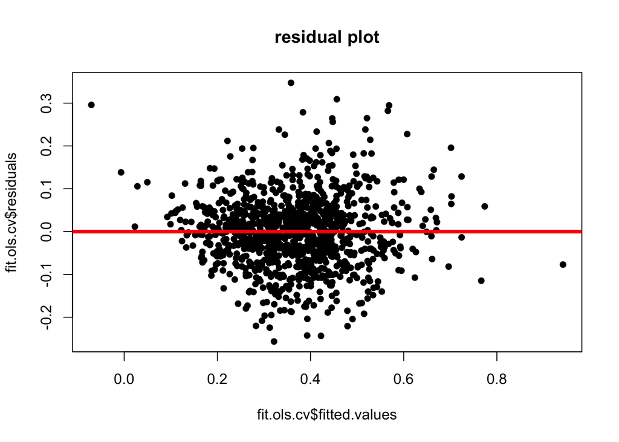

```r
#<<<<<<<<<< RESIDUAL PLOT -- LINEARITY & HOMOSCEDASTICITY >>>>>>>>>
plot(fit.ols.cv$fitted.values, fit.ols.cv$residuals,
     pch = 16,
     main = "residual plot")
abline(h=0, lwd=4, col="red")
```

Desirable residual plots are: (1) they’re pretty symmetrically distributed, tending to cluster towards the middle of the plot (2) they’re clustered around the lower single digits of the y-axis (e.g., 0.5 or 1.5, not 30 or 150) (3) in general there aren’t clear patterns These plots aren’t evenly distributed vertically, or they have an outlier, or they have a clear shape to them. If you can detect a clear pattern or trend in your residuals, then your model has room for improvement.

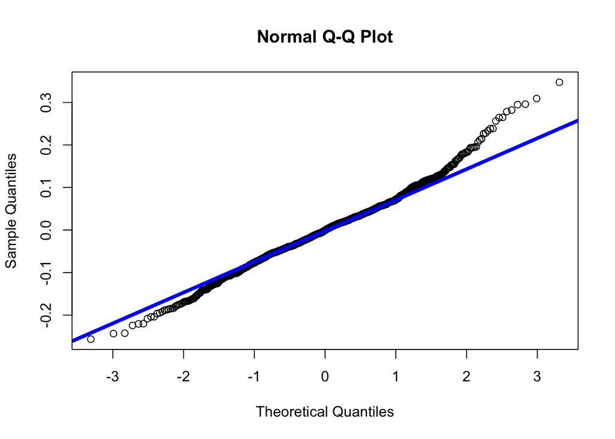

```r
#<<<<<<<< QQNORM PLOT FOR NORMALITY >>>>>>>>>
qqnorm(fit.ols.cv$residuals)
qqline(fit.ols.cv$residuals, lwd = 4, col="blue")
```

#### 3D)

```r
summary(fit.ols.cv)
```

```
##
## Call:
## lm(formula = dem12_frac ~ reg_vote_frac + turnout + hs_diploma_degree +
##     poverty_frac + caucasian_frac + uninsured + unemployment +
##     latino_frac + bachelors_degree + graduate_degree, data = county_data)
##
## Residuals:
##      Min       1Q   Median       3Q      Max
## -0.25667 -0.05071 -0.00065  0.04719  0.34741
##
## Coefficients:
##                   Estimate Std. Error t value Pr(>|t|)
## (Intercept)        0.07988    0.07371   1.084    0.279
## reg_vote_frac      0.24395    0.03295   7.404 2.67e-13 ***
## turnout            0.25769    0.03659   7.043 3.37e-12 ***
## hs_diploma_degree  0.59700    0.06015   9.925  < 2e-16 ***
## poverty_frac       0.79876    0.06463  12.360  < 2e-16 ***
## caucasian_frac    -0.50974    0.02476 -20.589  < 2e-16 ***
## uninsured         -1.65753    0.06885 -24.074  < 2e-16 ***
## unemployment       0.90250    0.11167   8.082 1.72e-15 ***
## latino_frac        0.14592    0.02890   5.049 5.22e-07 ***
## bachelors_degree  -0.59783    0.11128  -5.372 9.55e-08 ***
## graduate_degree    1.28870    0.23249   5.543 3.74e-08 ***
## ---
## Signif. codes:  0 '***' 0.001 '**' 0.01 '*' 0.05 '.' 0.1 ' ' 1
##
## Residual standard error: 0.08352 on 1066 degrees of freedom
## Multiple R-squared:  0.6637, Adjusted R-squared:  0.6605
## F-statistic: 210.4 on 10 and 1066 DF,  p-value: < 2.2e-16
```

## Part 3 Turnout

### Question 1

```r
names(county_data)
```

```
##  [1] "county"                "state"
##  [3] "total_votes_12"        "dem12_frac"
##  [5] "rep12_frac"            "total_population"
##  [7] "registered_voters"     "reg_vote_frac"
##  [9] "turnout"               "hs_diploma_degree"
## [11] "median_income"         "poverty_frac"
## [13] "caucasian_frac"        "gini_coefficient"
## [15] "median_age"            "adult_smoking"
## [17] "uninsured"             "unemployment"
## [19] "violent_crime"         "homicide_rate"
## [21] "infant_mortality"      "african_american_frac"
## [23] "latino_frac"           "bachelors_degree"
## [25] "graduate_degree"       "competitive_state_08"
## [27] "margin_state_08"
```

```r
lm.turnout <- lm(turnout~margin_state_08, data = county_data)
summary(lm.turnout)
```

```
##
## Call:
## lm(formula = turnout ~ margin_state_08, data = county_data)
##
## Residuals:
##      Min       1Q   Median       3Q      Max
## -0.39846 -0.06556 -0.00335  0.05887  0.28714
##
## Coefficients:
##                  Estimate Std. Error t value Pr(>|t|)
## (Intercept)      0.657264   0.005503 119.441   <2e-16 ***
## margin_state_08 -0.051898   0.037563  -1.382    0.167
## ---
## Signif. codes:  0 '***' 0.001 '**' 0.01 '*' 0.05 '.' 0.1 ' ' 1
##
## Residual standard error: 0.1002 on 1075 degrees of freedom
## Multiple R-squared:  0.001773,   Adjusted R-squared:  0.000844
## F-statistic: 1.909 on 1 and 1075 DF,  p-value: 0.1674
```

```r
Anova(lm.turnout)
```

```
## Anova Table (Type II tests)
##
## Response: turnout
##                  Sum Sq   Df F value Pr(>F)
## margin_state_08  0.0192    1   1.909 0.1674
## Residuals       10.8000 1075
```

#### 1A)

no it doesn’t.

#### 1B)

```r
lm.turnout2 <- lm(turnout~. -county -rep12_frac, data = county_data)
summary(lm.turnout2)
```

```
##
## Call:
## lm(formula = turnout ~ . - county - rep12_frac, data = county_data)
##
## Residuals:
##      Min       1Q   Median       3Q      Max
## -0.32962 -0.02091  0.00126  0.02175  0.22174
##
## Coefficients: (2 not defined because of singularities)
##                            Estimate Std. Error t value Pr(>|t|)
## (Intercept)               6.137e-01  4.874e-02  12.591  < 2e-16 ***
## stateGeorgia             -5.730e-02  9.792e-03  -5.852 6.50e-09 ***
## stateKentucky            -1.415e-01  1.054e-02 -13.418  < 2e-16 ***
## stateMaryland            -5.528e-02  1.178e-02  -4.693 3.05e-06 ***
## stateMichigan            -9.500e-02  9.709e-03  -9.784  < 2e-16 ***
## stateMissouri            -9.462e-02  9.964e-03  -9.496  < 2e-16 ***
## stateOhio                -4.940e-02  9.973e-03  -4.954 8.50e-07 ***
## stateOklahoma            -1.339e-01  1.086e-02 -12.332  < 2e-16 ***
## statePennsylvania        -1.006e-01  9.720e-03 -10.354  < 2e-16 ***
## stateTexas               -1.817e-01  1.054e-02 -17.243  < 2e-16 ***
## stateWisconsin            9.427e-02  1.008e-02   9.354  < 2e-16 ***
## total_votes_12            2.754e-07  8.402e-08   3.279 0.001078 **
## dem12_frac               -7.089e-02  1.781e-02  -3.981 7.35e-05 ***
## total_population         -9.299e-10  2.376e-08  -0.039 0.968789
## registered_voters        -1.991e-07  6.300e-08  -3.160 0.001621 **
## reg_vote_frac            -2.134e-01  2.019e-02 -10.568  < 2e-16 ***
## hs_diploma_degree         2.118e-02  3.275e-02   0.647 0.518060
## median_incomeLow         -1.064e-02  4.388e-03  -2.424 0.015505 *
## median_incomeMedium      -1.253e-02  3.541e-03  -3.540 0.000418 ***
## poverty_frac             -2.141e-01  4.070e-02  -5.260 1.75e-07 ***
## caucasian_frac            7.869e-02  3.216e-02   2.447 0.014578 *
## gini_coefficient         -3.438e-02  4.902e-02  -0.701 0.483254
## median_age                5.898e-03  4.327e-04  13.629  < 2e-16 ***
## adult_smoking            -9.174e-02  2.709e-02  -3.386 0.000735 ***
## uninsured                 8.741e-02  5.390e-02   1.622 0.105198
## unemployment             -3.722e-01  7.361e-02  -5.056 5.05e-07 ***
## violent_crime            -5.110e-06  8.883e-06  -0.575 0.565244
## homicide_rate             1.495e-04  4.508e-04   0.332 0.740310
## infant_mortality          1.105e-03  6.033e-04   1.831 0.067380 .
## african_american_frac     2.459e-01  3.421e-02   7.189 1.25e-12 ***
## latino_frac               3.873e-02  3.225e-02   1.201 0.230155
## bachelors_degree          2.019e-01  5.700e-02   3.542 0.000415 ***
## graduate_degree           1.200e-01  1.191e-01   1.008 0.313833
## competitive_state_08TRUE         NA         NA      NA       NA
## margin_state_08                  NA         NA      NA       NA
## ---
## Signif. codes:  0 '***' 0.001 '**' 0.01 '*' 0.05 '.' 0.1 ' ' 1
##
## Residual standard error: 0.03876 on 1044 degrees of freedom
## Multiple R-squared:  0.855,  Adjusted R-squared:  0.8506
## F-statistic: 192.4 on 32 and 1044 DF,  p-value: < 2.2e-16
```

```r
pred <- data.frame(state = 'Washington',
                   county = 'King',
                   margin_state_08 = .5765 - .4048) # margin calculated from dem - republican vote
pred
```

```
##        state county margin_state_08
## 1 Washington   King          0.1717
```

```r
predict(lm.turnout, pred, interval = 'prediction', se = FALSE)
```

```
##         fit       lwr       upr
## 1 0.6483526 0.4515543 0.8451508
```

## Declaration

By submitting this document you certify that you have complied with the University of Pennsylvania’s Code of Academic Integrity, to the best of your knowledge. You further certify that you have taken this exam under its sanctioned conditions, i.e. solely within the set exam room and within the time allotted.